# Informe del proyecto

**Estadística y probabilidades**

**Laboratorio**

[figure not shown]

# Introducción

## Relevancia

El análisis de la relación entre los hábitos, la gestión del estrés y el rendimiento académico en los estudiantes de UTEC en el ciclo académico 2022-2 es un tema de gran relevancia en el ámbito educativo actual. Los hábitos de estudio, la capacidad para manejar el estrés y el rendimiento académico son factores cruciales que pueden influir en el éxito y bienestar de los estudiantes. Comprender la relación entre estos aspectos es fundamental para identificar posibles áreas de mejora y diseñar estrategias efectivas de apoyo estudiantil. Además, este estudio podría proporcionar información valiosa a la comunidad académica y contribuir al desarrollo de programas de intervención y políticas educativas enfocadas en la mejora del rendimiento estudiantil. Nuestro proyecto tiene los siguientes objetivos:

## Objetivos

**Objetivo general:** - Analizar la relación entre los hábitos de estudio y de vida de los estudiantes de UTEC durante el ciclo académico 2022-2, y cómo se correlacionan con el manejo del estrés y el rendimiento académico.

**Objetivos específicos:** - Identificar los hábitos de estudio y de vida más comunes entre los estudiantes de UTEC durante el período académico 2022-2.

- Estudiar y comprender a través de gráficas las relaciones compartidas entre hábitos y gestión de estrés; hábitos y rendimiento académico; y estrés y rendimiento académico de los estudiantes de UTEC del período académico 2022-2.
- Evaluar la fiabilidad y validez de los datos recopilados sobre los hábitos de estudio y la gestión de los estudiantes de UTEC durante el ciclo académico 2022-2, mediante la aplicación de pruebas estadísticas y técnicas de análisis de datos, como factores predictivos del rendimiento académico, es decir, que tienen influencia real sobre estos últimos.

## Contexto

El proyecto necesita comprender y analizar la relación existente entre los hábitos, la gestión del estrés y el rendimiento académico en los estudiantes universitarios. Para realizar la investigación del proyecto, es fundamental tener conocimientos sólidos sobre psicología educativa, psicología del aprendizaje, salud mental y técnicas de investigación en el ámbito educativo. Asimismo, se requiere comprender las teorías y modelos relacionados con los hábitos de estudio, el estrés académico y su impacto en el rendimiento académico. Además, es esencial familiarizarse con herramientas y metodologías para recopilar datos, como la encuesta que realizamos para tener una base de datos, y utilizar técnicas de análisis estadístico para examinar la relación entre las variables estudiadas. Este contexto de conocimiento proporciona la base necesaria para comprender y abordar de manera integral el análisis de la relación entre los hábitos, la gestión del estrés y el rendimiento académico en los estudiantes.

# Datos

## Recolección de datos

Realizamos la recolección de datos a través de un Formulario de Google (se puede acceder a él a través del siguiente enlace: https://forms.gle/1pV7ZPxskoUBCs1j8). Se decidió emplear este método por su facilidad para ser compartido, porque nos permite descargar los datos obtenidos a formato csv directamente y porque es bastante conocido por el público objetivo. Se llegó a la población a través de un contacto directo (amigos y conocidos).

## Población, muestra y muestreo

Nuestra población son los estudiantes de UTEC que cursaron el ciclo 2022-2, y las unidades muestrales, cada alumno encuestado.Se consiguieron 155 participaciones a través de un *muestreo a conveniencia* dada nuestra restricción de recursos.

## Variables

A continuación presentamos las variables analizadas, durante el procesamiento de la base de datos, se cambiaron los nombres a otros más sencillos y manejables (entre paréntesis).

## Limpieza de base de datos

Una vez obtenidas las respuestas a la encuesta, se realizan distintos pasos para obtener una base de datos limpia y manejable. Listamos estos pasos a continuación:

1. Cambiamos las observaciones de las variables de respuesta Sí/No (*Tiene Horario, Asesorias, Medita, si deporte*) a TRUE / FALSE, respectivamente. Por ejemplo, para la variable “*Tiene horario*”, usamos el siguiente código:

```r
DT1 %>% mutate(`Tiene horario` =
        ifelse(`Tiene horario` =="Sí",TRUE,
        ifelse(`Tiene horario` == "No",FALSE, NA
               ))) -> DT1
```

2. Empleando la función factor() y el argumento levels, ordenamos las variables ordinales (*Estres, cumplio_exp, Ciclo, Desvelado*).Por ejemplo, para la variable “*cumplio_exp*”, usamos el siguiente código:

```r
DT1$cumplio_exp <- factor(DT1$cumplio_exp, levels = c("1 (No las cumplí)", "2 (No las cumplí pero estuve cerca)", "3 (Las cumplí)", "4 (Las superé)", "5 (Las superé por bastante)"), ordered = TRUE)
```

3. Buscamos y transformamos a NA los valores anómalos de las variables numéricas (*Edad, Promedio, Agua, Horas de sueño, Horas deporte, Tiempo de viaje, Cafe, Horas de estudio*). Empleamos al función mutate() de la libreria dplyr; una función ifelse(); las funciones max() y min(); y plot() según el tipo de variable analizada, se usó gráficos de tipo boxplot e histograma.Por ejemplo, para la variable “*Horas de estudio*” se empleó el siguiente código:

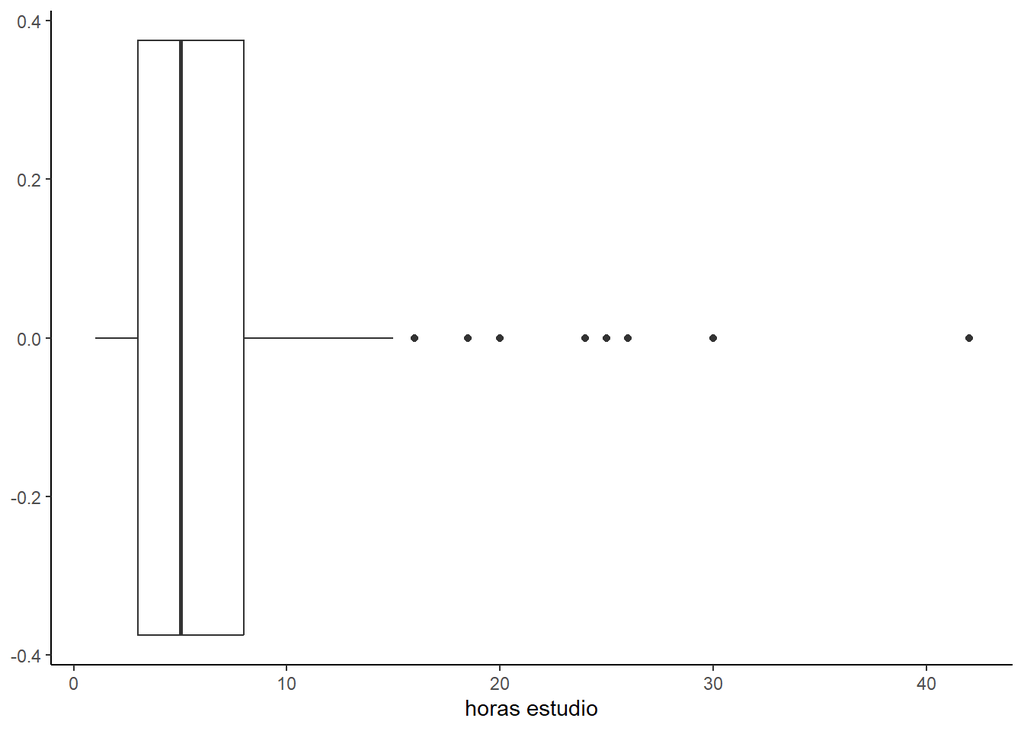

```r
DT1 %>% mutate(`horas estudio` =
        ifelse(`horas estudio` > 60, NA, `horas estudio`)) -> DT1

DT1 %>% ggplot(., aes(`horas estudio`)) + geom_boxplot() + theme_classic()
```

```r
max(DT1$`horas estudio`, na.rm = TRUE)
```

```
## [1] 42
```

```r
min(DT1$`horas estudio`, na.rm = TRUE)
```

```
## [1] 1
```

Con la información del gráfico, y de max() y min(), encontramos los valores que no son correctos. Luego, con las 2 primeras líneas de código los eliminamos cambiándolos por NA.

4. Para las variables de opción múltiple, se crean nuevas variables. Cada una representa una de las opciones y tiene un valor de TRUE/FALSE, según el participante haya o no elegido tal opción. A continuación se muestran las variables a las que se aplicó este caso y las nuevas columnas resultantes:
   - **lid_estres:**
     - Dormir
     - Musica
     - Videojuegos
     - Salir_amigos
     - Caminar
     - Otros
   - **Metodos_estudio:**
     - Pomodoro
     - Feynman
     - Resumen_mapa
     - Spaced_repetition
     - Método_de_Cornell
     - Mnemotecnias
     - SQ3R
     - Ninguno
   - **Material:**
     - Material_profesor
     - Libros
     - Material_audiovisual
     - Recursos_Linea
     - Apuntes
     - Material_Asesoria
     - Material_Mentorias  
       Esto se consiguió a través del siguiente código (ejemplo del código para *lid_estres*):

```r
DT1<-mutate(DT1,Dormir=grepl("Dormir",lid_estres),
            DT1,Musica=grepl("Escuchar música",lid_estres),
            DT1,Videojuegos=grepl("Jugar videojuegos",lid_estres),
            )
DT1<-mutate(DT1,Salir_Amigos=grepl("Salir / Llamar a amigos o familiares",lid_estres),
            DT1,Caminar=grepl("Salir a caminar",lid_estres),
            DT1,Otros=grepl("Otros",lid_estres),
)
```

5. En cuanto al manejo de NAs, en la mayoría de las variables, se dejaron como tales, para no interferir con los cálculos de los descriptores. Sin embargo, se realizaron pruebas de porcentajes de NAs para determinar qué tanto afectan a los resultados del informe. La única variable para la cual se realizó un manejo especial de NAs es para *Horas deporte*. Esta variable es condicional de *si deporte*, si el encuestado respondió que no hace deporte, lo lógico es considerar que el valor adecuado para *Horas deporte* es 0. Se empleó el siguiente código.

```r
DT1 <- mutate(DT1, `Horas deporte` = ifelse(is.na(`Horas deporte`), 0, `Horas deporte`))

DT1 %>% select(`Horas deporte`)
```

6. Finalmente, se renombraron las opciones de la variable estrés a números del 0 al 3. Esto sirve para que al momento de realizar gráficas no tengamos nombres tan largos que se sobrepongan. Para ello empleamos el siguiente código.

```r
DT1 %>% mutate(Estres = ifelse(Estres == "Nada estresado / Tranquilo", "0",
                               ifelse(Estres == "Algo estresado", "1",
                                      ifelse(Estres == "Estresado", "2", ifelse(Estres=="Sáquenme de UTEC D: (alto nivel de estrés)", "3", NA)
                               )))) -> DT1
```

# 3. Análisis descriptivo.

## 3.1 Análisis univariado.

- **GRAFICA 1- Cantidad de estudiantes por carrera**

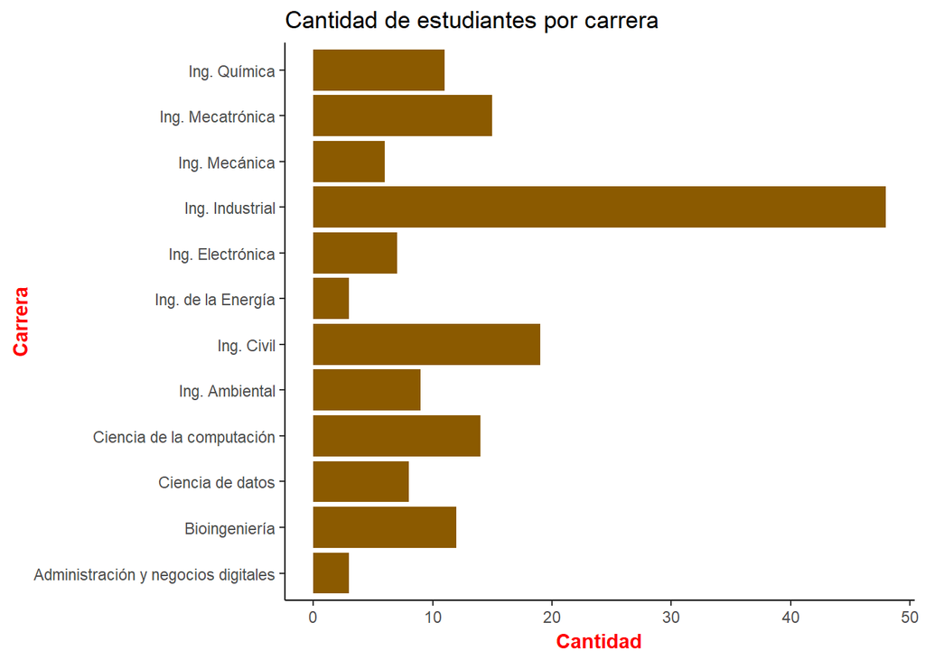

Del total de encuestados 48 estudiantes son de las carrera de ingeniería industrial, es la carrera que más se repite y es la moda de nuestra gráfica *cantidad de estudiantes por carrera*, mientras que tuvimos menos participación de los estudiantes de la carrera de administración y negocios digitales, y de la carrera de Ing. de la Energía, puesto que solo fueron 3 encuestados en ambas carreras.

**GRÁFICA 2 - Edad de los estudiantes encuestados**

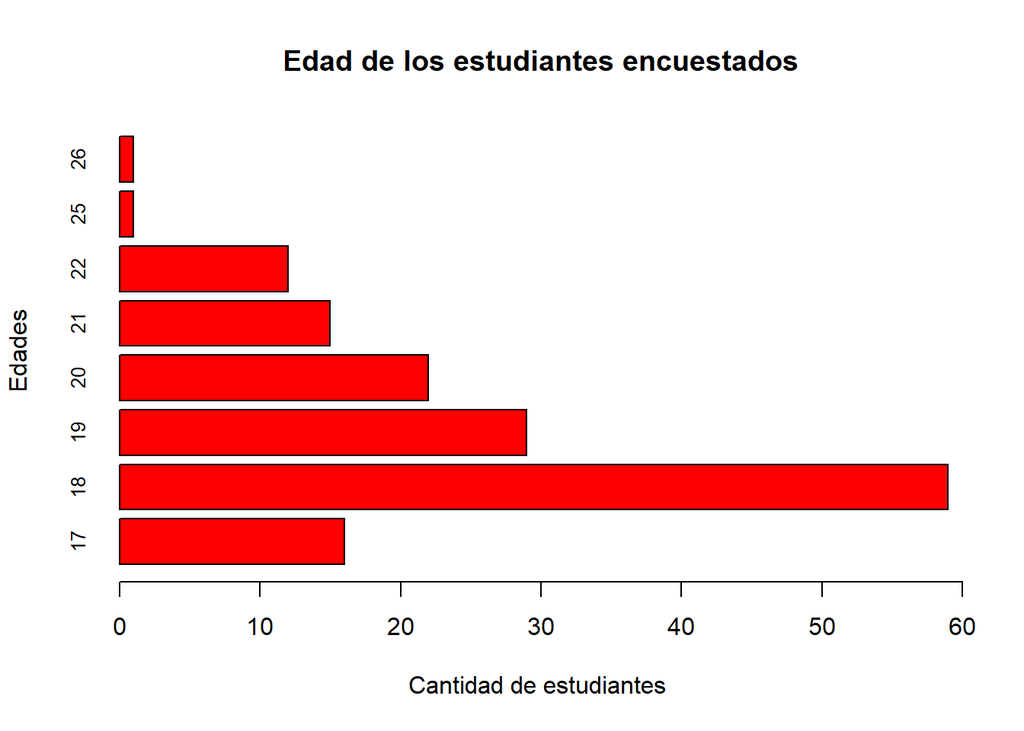

La edad de nuestros encuestados esta entre 17 y 26 años,pero la edad que mas se repite y es la moda de nuestra variable es de *18* años con 59 encuestados, las edades que poca participación tuvieron es de 25 y 26 años, ambos contando solo con 1 encuestado.

**GRÁFICA 3 - Preferencias para aliviar el estrés.**

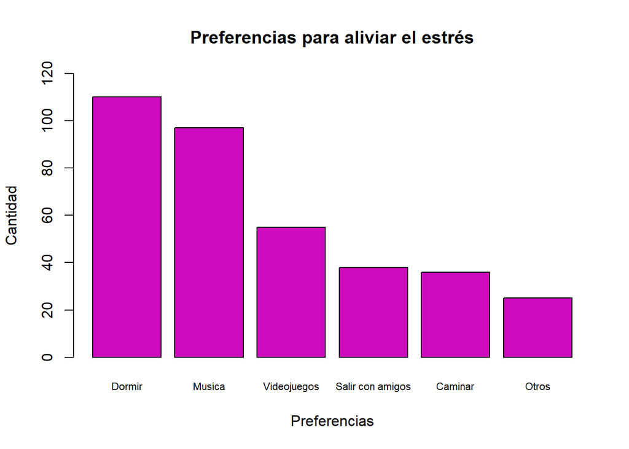

- **JUSTIFICACIÓN**

Durante el ciclo o periodo académico los estudiantes suelen estresarse por la carga académica, y buscan la mejor forma de aliviar con estos, es por ellos que en la gráfica les mostramos las preferencias que practican para lidiar con este problema(el estrés).

- **ANÁLISIS.**

**GRÁFICA 4 - Métodos de estudio que utilizaron**

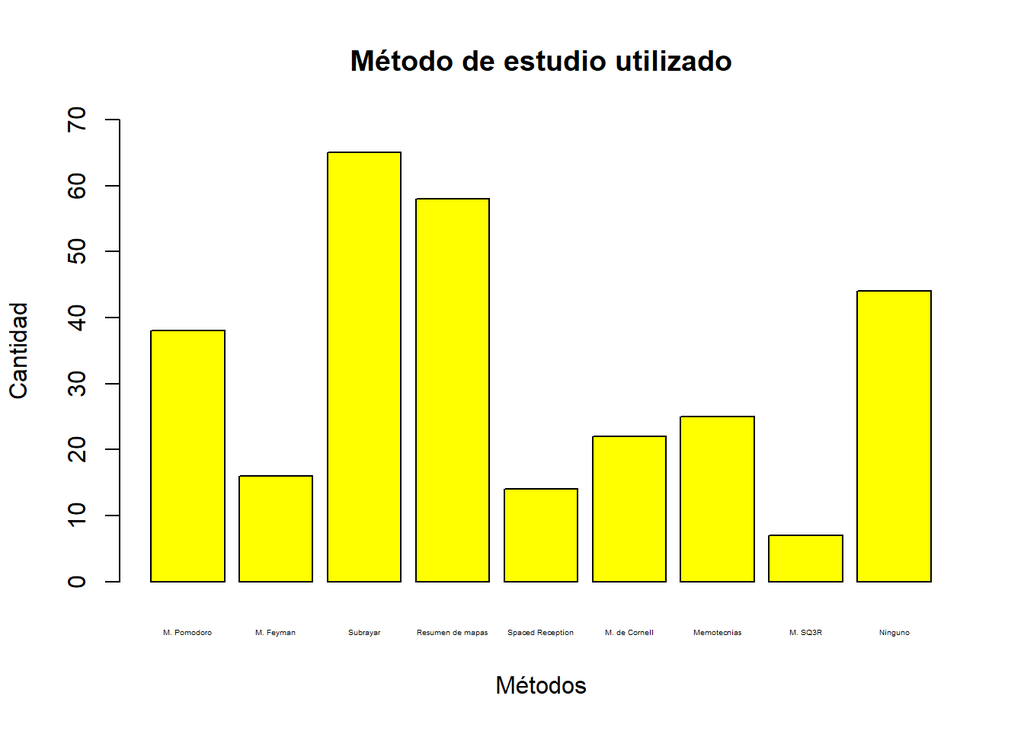

- **JUSTIFICACIÓN**

-Esta gráfico de barras nos muestra los distintos métodos de estudio empleado por los estudiante de la UTEC durante el periodo académico 2022-2.

- **ANÁLISIS.**

-De esta gráfica de métodos de estudios utilizados, podemos apreciar que subrayar es el método más utilizado por los estudiantes, mientras que el método de SQ3R es el método menos utilizado. Asimismo, podemos apreciar que una cantidad de estudiantes no utilizan ningún método de estudio y es el tercero en cantidad.  
-La moda de Métodos de estudio utilizados es el método *Subrayar*, con una preferencia de 65 estudiantes. El segundo método que tuvo popularidad es *Resumen de mapas* con una presencia de 58 estudiantes.  
-Unos 44 alumnos no utilizan ningunos de los métodos propuestos.

**GRÁFICA 5 - Material empleado durante el ciclo**

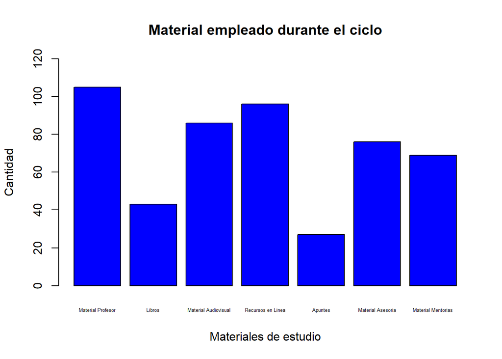

- **JUSTIFICACIÓN**

Uno como estudiante busca la mejor forma de reforzar y fortalecer sus conocimientos aprendidos en aula, y para ello uno emplea distintos materiales de estudio.

- **ANÁLISIS**

-En esta tabla podemos apreciar que el material entregado por los profesores es el mayor utilizado y los apuntes son el método menos empleado por los estudiantes.  
-La moda en esta gráfica es *Material Profesor*, que son los materiales entregados en clase o subidas al Canvas por el docente del curso.  
-La cantidad de estudiantes que utilizan los materiales del profesor es de 105.  
-El material menos utilizado es *Apuntes*, ya que solo 27 alumnos lo utilizan.

- *Podemos señalar que la mayor preferencia del material empleado durante el ciclo oscila entre el material entregado por el profesor, el material audiovisual y recursos en línea.*

**GRÁFICA 6 - Nivel de estrés durante el ciclo**

[figure not shown]

- **ANÁLISIS**

-En la gráfica de niveles de estrés durante el ciclo, podemos apreciar que el nivel de estrés de los estudiantes en su mayoría es estresado o algo estresado, además el nivel de estrés de una minoría de estudiantes ha sido tranquilo.  
-La cantidad de estudiantes que estuvieron *algo estresado* de es 57, mientras que la cantidad de *estresado* es de 56.  
- Solo 7 alumnos del total de encuestados no sufrieron de *Estrés*.

- **HISTOGRAMA - Promedio Ponderado**

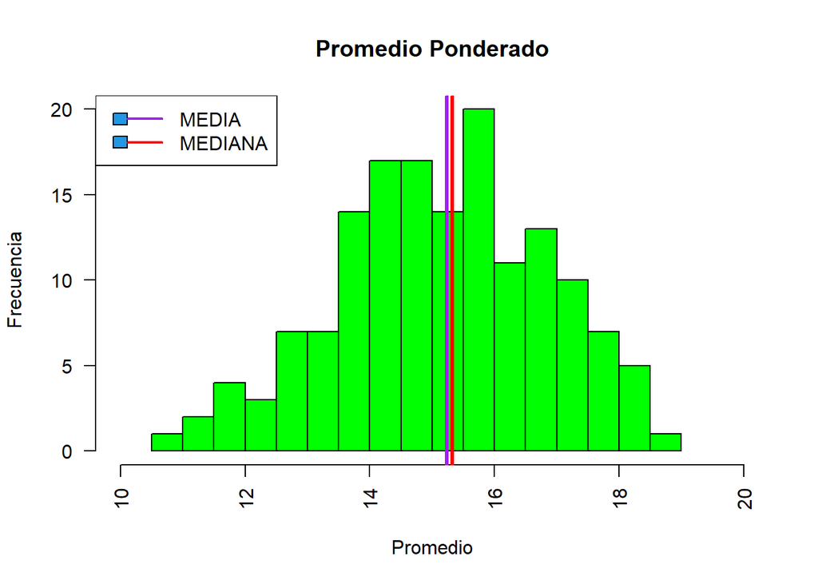

- **ANÁLISIS**
- La gráfica muestra que el promedio oscila entre 10.51 y 18.75, [10.51 - 18.75]. Podemos decir que el mínimo promedio ponderado es de 10.51 mientras que el máximo es de 18.75 durante el ciclo académico 2022-2.

```
## [1] 10.51 18.75
```

- El valor central o mediana del promedio ponderado de los alumnos es de 15.32.

```
## [1] 15.32
```

- El valor del promedio general o media aritmética de las notas es 15.24

```
## [1] 15.24
```

*Al comparar la mediana con la media aritmética del promedio Ponderado de los alumnos, podemos apreciar que la mediana es mayor que la media, lo cual nos indica que la distribución de los valores tiende a estar inclinada o sesgada hacia la izquierda*

### Porcentajes de N.A. de las variables

Para entender mejor los sesgos que puede tener nuestra investigación, realizamos un análisis de la cantidad de NAs de las variables:

Porcentaje de N.A de la variable “cantidad curso”

```
## [1] 5.806452
```

Porcentaje de N.A de la variable “Horas sueño”

```
## [1] 7.741935
```

Porcentaje de N.A de la variable “Horas deporte”

```
## [1] 0
```

Porcentaje de N.A de la variable “Cafe”

```
## [1] 1.290323
```

Porcentaje de N.A de la variable “horas estudio”

```
## [1] 0.6451613
```

Porcentaje de N.A de la variable “cumplio_expectativa”

```
## [1] 1.290323
```

Porcentaje de N.A de la variable “Promedio”

```
## [1] 1.290323
```

Porcentaje de N.A de la variable “Agua”

```
## [1] 1.290323
```

### Hábitos más comunes

Para concluir con el análisis univariado, presentamos los hábitos y carácterísticas más comunes entre la población encuestada, o, lo que es lo mismo, las características medias de los encuestados (usando las medias y modas de las variables.

Las características medias de los encuestados son:

- Tiene 19 años
- Estudia Ingeniería Industrial
- Cumplió sus expectativas (sin superarlas ni quedar atrás)
- Tiene un promedio de 15,24
- Está en 3er ciclo
- Toma 1327 mL de agua al día
- Tiene un horario de estudio
- Duerme 6 horas cada noche
- Hace 2,6 h de deporte a la semana
- Demora 45,77 minutos en llegar a la universidad
- No medita
- Toma 3,5 tazas de café a la semana
- Lleva 6 cursos
- Asiste a asesorías
- Estudia 7 horas a la semana fuera de su horario de clases
- Estudia en su casa mayormente
- Se ha desvelado de 4 a 7 veces
- Usa material entregado por el profesor, audiovisual y recursos en línea para estudiar
- Duerme y escucha música para lidiar con el estrés
- (No existe una tendencia marcada para los métodos de estudio que se emplean)

## 3.2 Análisis bivariado

**GRÁFICA - Comparación entre calificación de expectativas y horas de sueño**

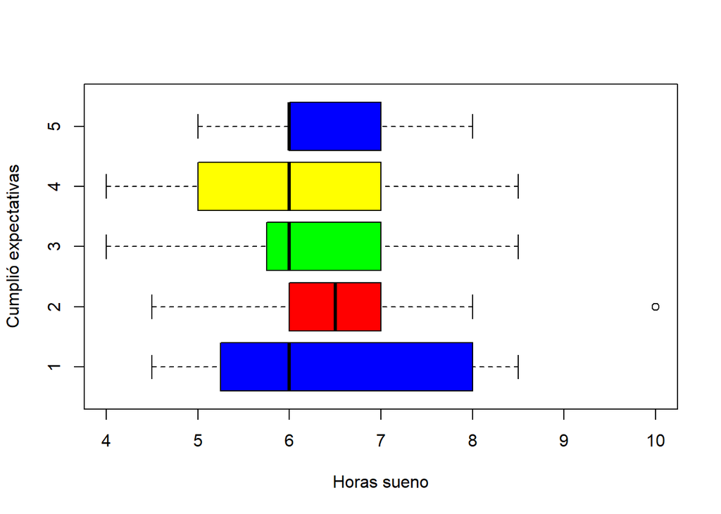

- **JUSTIFICACIÓN**

El análisis se centra en comparar las horas de sueño con la percepción del cumplimiento de las expectativas académicas. Esta comparación puede ser relevante para evaluar si existe alguna relación entre las horas de sueño y la satisfacción con el grado en que las expectativas académicas son alcanzadas.

- **ANÁLISIS**

El gráfico muestra la comparación entre las horas de sueño y la percepción del cumplimiento de las expectativas académicas.

Para evaluar la percepción sobre el cumplimiento de las expectativas, se utilizó una calificación que refleja el grado en que los estudiantes consideran que sus expectativas académicas han sido alcanzadas. Esta calificación puede interpretarse como la satisfacción subjetiva de los estudiantes con el cumplimiento de sus expectativas.

Se observa que aquellos encuestados que no cumplieron con sus expectativas académicas tuvieron una mayor cantidad de horas de sueño en comparación con los que sí cumplieron sus expectativas. Esta relación sugiere que existe una posible asociación entre el no cumplimiento de las expectativas académicas y un mayor tiempo dedicado al sueño. Sin embargo, es importante destacar que se necesita realizar un análisis más exhaustivo y considerar otros factores antes de establecer conclusiones definitivas.

**GRÁFICA - Comparación entre calificación de expectativas y tiempo de viaje**

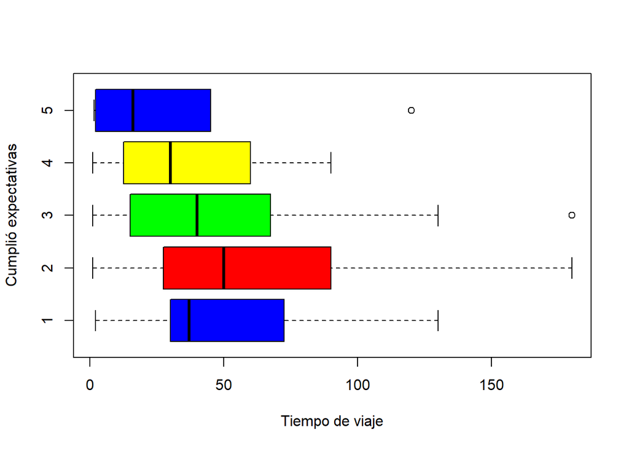

- **JUSTIFICACIÓN**

El objetivo de este análisis es examinar la posible relación entre el tiempo de viaje de los alumnos y su percepción sobre el cumplimiento de sus expectativas académicas. El tiempo de viaje es un factor relevante en la vida de los estudiantes, y entender cómo puede influir en su satisfacción con el cumplimiento de las expectativas puede brindar información valiosa para mejorar la experiencia académica.

- **ANÁLISIS**

La gráfica presenta una comparación entre el tiempo de viaje de los alumnos y su percepción sobre el cumplimiento de sus expectativas académicas.

Podemos considerar que aquellos con un tiempo de viaje más corto tienden a sentir que sus expectativas son cumplidas en mayor medida, mientras que aquellos con un tiempo de viaje más largo pueden experimentar un menor cumplimiento de sus expectativas.

**GRÁFICA - Comparación entre calificación de expectativas y promedio ponderado**

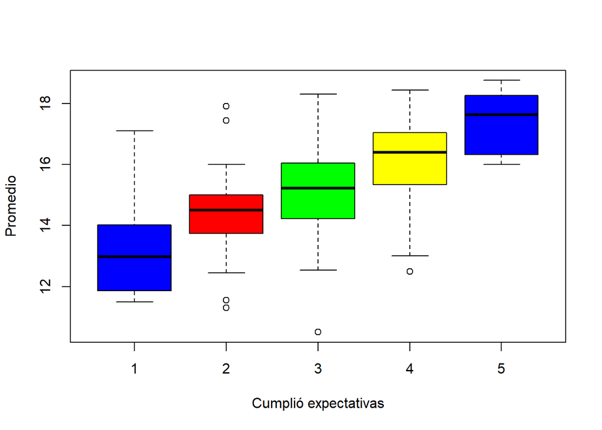

- **JUSTIFICACIÓN**

El análisis se centra en comparar el rendimiento académico promedio de los alumnos con su percepción sobre el cumplimiento de sus expectativas académicas. Esta comparación puede ser relevante para evaluar si existe alguna relación entre el rendimiento académico y la satisfacción con el grado en que las expectativas académicas son alcanzadas.

- **ANÁLISIS**

La gráfica muestra la comparación entre el rendimiento académico promedio de los alumnos y su percepción sobre el cumplimiento de sus expectativas académicas.

Para evaluar la percepción sobre el cumplimiento de las expectativas, se utilizó una calificación que refleja el grado en que los estudiantes consideran que sus expectativas académicas han sido alcanzadas. Esta calificación puede interpretarse como la satisfacción subjetiva de los estudiantes con el cumplimiento de sus expectativas.

El rendimiento académico se representa mediante un promedio, que refleja el desempeño general de los estudiantes en términos de las calificaciones obtenidas en sus cursos.

Al comparar el rendimiento académico promedio con la calificación de la percepción de cumplimiento de expectativas, se busca explorar si existe alguna relación entre la satisfacción con el grado en que las expectativas son alcanzadas y el rendimiento académico. Por ejemplo, se podría analizar si los estudiantes que perciben un mayor cumplimiento de sus expectativas académicas también obtienen un rendimiento académico más alto.

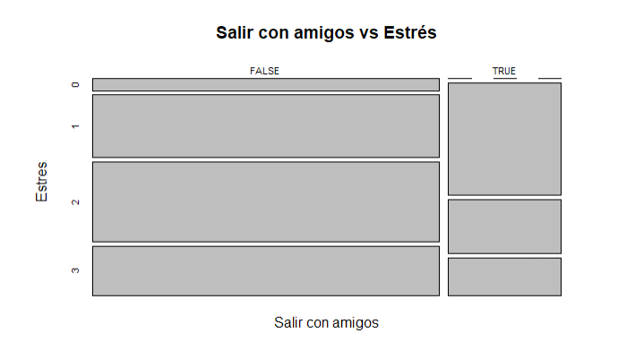

Gráfico de mosaico (Aclaración: knit no permite ejecutar el código de arriba, por ello decidimos colocar la imagen directamente. El código funciona a la perfección en RStudio.)

- **JUSTIFICACIÓN**

- **ANÁLISIS**

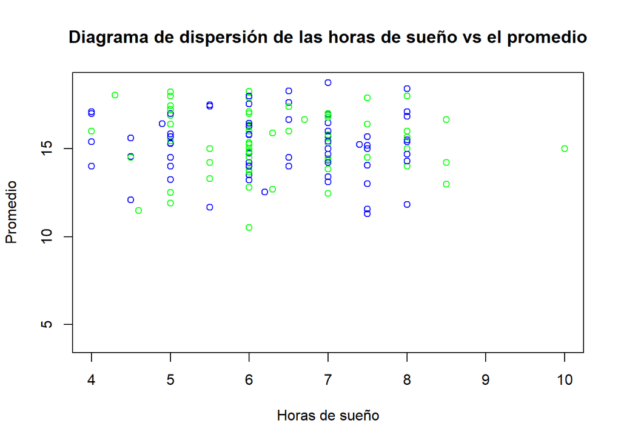

- **JUSTIFICACIÓN**

Este es un caso de análisis de 2 variables numéricas: Las horas de sueño y el promedio de los alumnos. Para el análisis de este tipo de variables, se empleó un gráfico de dispersión.

- **ANÁLISIS**

Este gráfico muestra que no hay una relación significativa entre las variables. No muestran ninguna tendencia. En caso hubiese una, los puntos aparecerían aproximadamente alrededor de una diagonal.